# Cyclistic Bike-Share Analysis

Rodrigo Willrich Gehlen

Completed: 2025-07-16 Last updated: 2025-08-20

## About Cyclistic

In 2016, Cyclistic launched a successful bike-share offering. Since then, the program has grown to a fleet of 5,824 bicycles that are geotracked and locked into a network of 692 stations across Chicago. The bikes can be unlocked from one station and returned to any other station in the system anytime.

Until now, Cyclistic’s marketing strategy relied on building general awareness and appealing to broad consumer segments. One approach that helped make these things possible was the flexibility of its pricing plans: single-ride passes, full-day passes, and annual memberships. Customers who purchase single-ride or full-day passes are referred to as casual riders. Customers who purchase annual memberships are Cyclistic members.

## Ask

### Business Task

The Cyclistic marketing team wants to understand how **casual riders** and **annual members** use Cyclistic bikes differently. The goal is to design a marketing strategy that **converts casual riders into annual members**, improving long-term revenue and engagement.

## Prepare

### Data Source

The data is collected from City of Chicago’s Divvy bycicle sharing service and made available by Motivate International Inc. under this [license](https://divvybikes.com/data-license-agreement). This service is operated by Lyft Bikes and Scooters, LLC. This analysis is based on historical data from 2019 and 2020.

The yearly data is originally organized in separate tables containing the following:

- 2019 trips: 365.069 observations and 12 variables
- 2020 trips: 426.887 observations and 14 variables

Each row represents a single ride.

Original data is publicly available at [this link](https://divvy-tripdata.s3.amazonaws.com/index.html).

The raw Divvy datasets are not stored in this repository due to file size limits.

If you’d like to **run the code in the R Markdown file**, please:

1. Download the datasets from the links below:
   - [trips_2019_q1.csv](https://divvy-tripdata.s3.amazonaws.com/Divvy_Trips_2019_Q1.zip)
   - [trips_2020_q1.csv](https://divvy-tripdata.s3.amazonaws.com/Divvy_Trips_2020_Q1.zip)
2. Unzip and place the `.csv` files into the `data/` folder at the root of this repository. Make sure the names match those expected in the R script.

This will ensure the R Markdown code runs without errors.

## Process

### Setting Up

Load libraries and read both dataframes:

```r
library(tidyverse)
library(lubridate)

trips_2019 <- read.csv("data/trips_2019_q1.csv")
trips_2020 <- read.csv("data/trips_2020_q1.csv")
```

### Combining Data

This will allow to take every step of cleaning processes at once.

Before running the `bind_rows` function, it is important to ensure that **variables do have exactly the same name** and its **data is stored as the same type**:

```r
trips_2019 <- trips_2019 %>%
  rename(
    ride_id = trip_id,
    started_at = start_time,
    ended_at = end_time,
    start_station_name = from_station_name,
    start_station_id = from_station_id,
    end_station_name = to_station_name,
    end_station_id = to_station_id,
    member_casual = usertype
  )
```

```r
trips_2019 <- trips_2019 %>%
  mutate(ride_id = as.character(ride_id))
```

In order to identify each data source after combining, a new variable `year` were created:

```r
trips_2019 <- trips_2019 %>%
  mutate(year = "2019")
trips_2020 <- trips_2020 %>%
  mutate(year = "2020")
```

Unnecessary columns were removed to save memory usage as well:

```r
trips_2019 <- trips_2019 %>%
  select(
    -bikeid,
    -gender,
    -birthyear
  )
trips_2020 <- trips_2020 %>%
  select(
    -rideable_type,
    -start_lat,
    -start_lng,
    -end_lat,
    -end_lng
  )
```

Now both dataframes are ready to be combined:

```r
divvy_trips <- bind_rows(trips_2019, trips_2020)
```

### Cleaning Data

To make sure that any analysis will result in reliable information, **duplicates** and **missing values** have to be identified:

```r
sum(duplicated(divvy_trips$ride_id))
```

```
## [1] 0
```

```r
colSums(is.na(divvy_trips))
```

```
##            ride_id         started_at           ended_at       tripduration
##                  0                  0                  0             426887
##   start_station_id start_station_name     end_station_id   end_station_name
##                  0                  0                  1                  0
##      member_casual               year
##                  0                  0
```

All of the `tripduration` missing values comes from 2020 table, so that variable were updated:

```r
divvy_trips <- divvy_trips %>%
  mutate(tripduration = difftime(ended_at, started_at, "seconds"))
```

To prevent calculation issues, data types were also updated:

```r
divvy_trips <- divvy_trips %>%
  mutate(
    started_at = ymd_hms(started_at),
    ended_at = ymd_hms(ended_at),
    tripduration = as.numeric(tripduration),
    member_casual = as.factor(member_casual)
  )
```

Note that `member_casual` factor now have four levels and need to be adjusted:

```r
divvy_trips <- divvy_trips %>%
  mutate(member_casual = recode(member_casual,
                                "Subscriber" = "member",
                                "Customer" = "casual"))
```

Numeric range of `tripduration` includes negative numbers that are all related to HQ QR station (ID 675). As the analysis will be focused on **customer rides**, those rows were removed:

```r
divvy_trips <- divvy_trips %>%
  filter(!(start_station_id == 675))
```

## Analyze

Descriptive analysis were conducted to understand how **casual riders** and **annual members** use Cyclistic bikes differently.

The total number of rides was calculated for each user type to understand the overall distribution between members and casual users:

```r
divvy_trips %>%
  count(member_casual, name = "total_rides") %>%
  mutate(percent = round(100 * total_rides / sum(total_rides)))
```

```
##   member_casual total_rides percent
## 1        casual       67877       9
## 2        member      720312      91
```

The average trip duration was calculated for each user type to compare ride lengths and gain insight into how each group typically uses the service:

```r
divvy_trips %>%
  filter(tripduration >= 60 & tripduration <= 1200) %>%
  group_by(member_casual) %>%
  summarise(avg_duration_min = round(mean(tripduration) / 60))
```

```
## # A tibble: 2 × 2
##   member_casual avg_duration_min
##   <fct>                    <dbl>
## 1 casual                      12
## 2 member                       9
```

The proportion of round trips—where the start and end stations are the same—was calculated for each user type. This helps explore behavioral differences, such as whether rides are point-to-point or recreational loops:

```r
divvy_trips %>%
  mutate(round_trip = start_station_id == end_station_id) %>%
  count(member_casual, round_trip) %>%
  group_by(member_casual) %>%
  mutate(percent = round(100 * n / sum(n))) %>%
  filter(round_trip)
```

```
## # A tibble: 2 × 4
## # Groups:   member_casual [2]
##   member_casual round_trip     n percent
##   <fct>         <lgl>      <int>   <dbl>
## 1 casual        TRUE        9713      14
## 2 member        TRUE       13913       2
```

The number of trips was summarized for each weekday and user type to examine weekly usage patterns and identify differences in ride frequency across the week:

```r
divvy_trips %>%
  mutate(
    weekday = wday(started_at, label = TRUE, abbr = FALSE),
    weekday = factor(weekday, levels = c(
      "Monday", "Tuesday", "Wednesday", "Thursday", "Friday", "Saturday", "Sunday"
    ))
  ) %>%
  group_by(weekday, member_casual) %>%
  summarise(total_trips = n(), .groups = "drop")
```

```
## # A tibble: 14 × 3
##    weekday   member_casual total_trips
##    <ord>     <fct>               <int>
##  1 Monday    casual               5591
##  2 Monday    member             110430
##  3 Tuesday   casual               7311
##  4 Tuesday   member             127974
##  5 Wednesday casual               7690
##  6 Wednesday member             121902
##  7 Thursday  casual               7147
##  8 Thursday  member             125228
##  9 Friday    casual               8013
## 10 Friday    member             115168
## 11 Saturday  casual              13473
## 12 Saturday  member              59413
## 13 Sunday    casual              18652
## 14 Sunday    member              60197
```

The average trip duration was calculated by weekday and user type to assess how ride length varies over the week and between user groups:

```r
divvy_trips %>%
  filter(tripduration >= 60 & tripduration <= 1200) %>%
  mutate(
    weekday = wday(started_at, label = TRUE, abbr = FALSE),
    weekday = factor(weekday, levels = c(
      "Monday", "Tuesday", "Wednesday", "Thursday", "Friday", "Saturday", "Sunday"
    ))
  ) %>%
  group_by(weekday, member_casual) %>%
  summarise(avg_duration_min = round(mean(tripduration) / 60), .groups = "drop")
```

```
## # A tibble: 14 × 3
##    weekday   member_casual avg_duration_min
##    <ord>     <fct>                    <dbl>
##  1 Monday    casual                      11
##  2 Monday    member                       8
##  3 Tuesday   casual                      11
##  4 Tuesday   member                       9
##  5 Wednesday casual                      11
##  6 Wednesday member                       9
##  7 Thursday  casual                      11
##  8 Thursday  member                       8
##  9 Friday    casual                      11
## 10 Friday    member                       8
## 11 Saturday  casual                      12
## 12 Saturday  member                       9
## 13 Sunday    casual                      13
## 14 Sunday    member                       9
```

## Share

### Ride Distribution by User Type

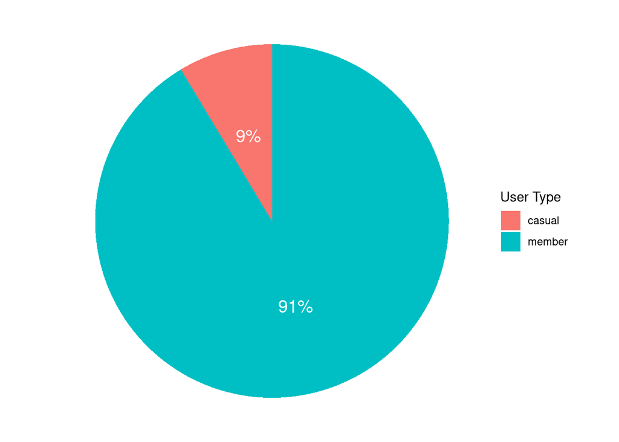

The chart shows that members make up the vast majority of total rides, while casual users account for a much smaller share. This indicates that the service is primarily used by subscribed members, suggesting frequent or routine use, such as commuting.

### Average Trip Duration by User Type

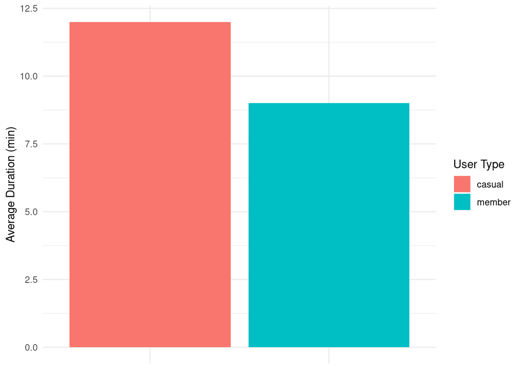

Casual users have longer average trip duration compared to members. This supports the idea that casual users are more likely engaging in leisure or recreational rides, while members tend to take shorter trips, possibly for commuting or other regular purposes.

### Round Trips Percentage by User Type

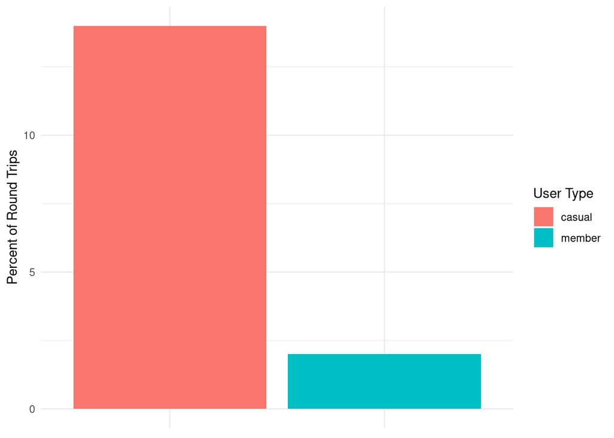

A higher percentage of casual users’ rides are round trips, whereas very few member rides start and end at the same station. This pattern further supports the assumption that casual users are more likely using the service for recreational activities, while members tend to use it for point-to-point travel such as commuting.

### Total Trips per Weekday by User Type

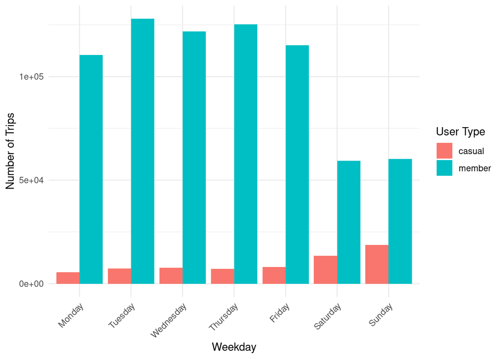

Members show consistent ride activity throughout the weekdays, with noticeable peaks on typical workdays, suggesting commuting behavior. In contrast, casual users are most active during weekends, indicating that their usage is likely driven by leisure and non-work-related purposes.

### Average Trip Duration per Weekday by User Type

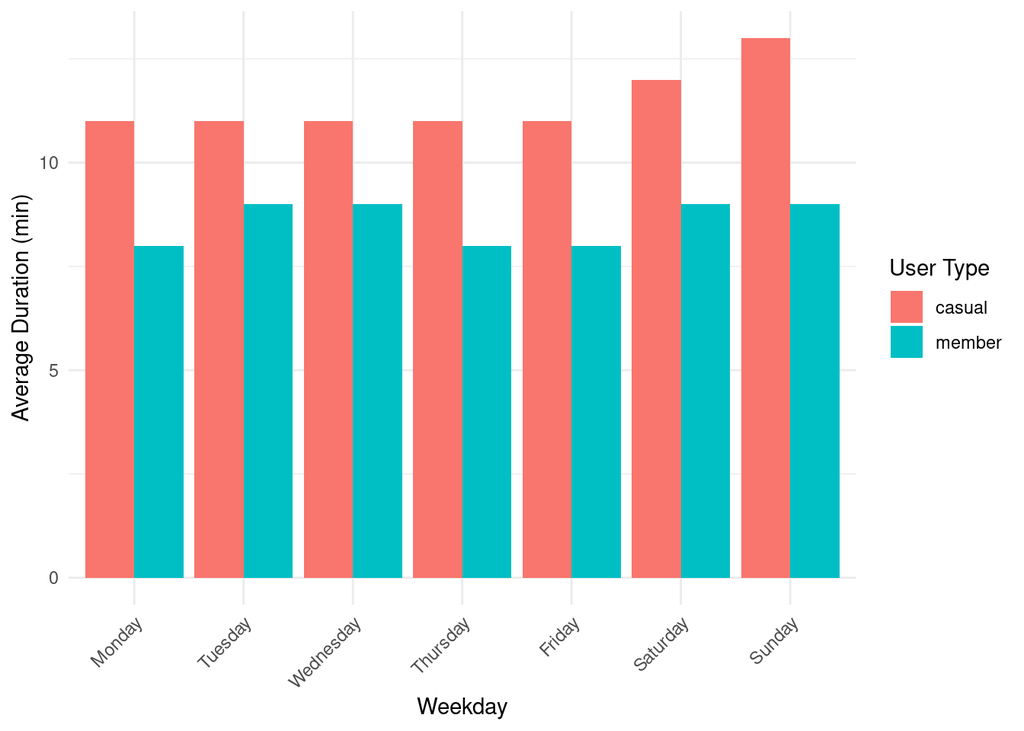

The average trip duration for casual users is consistently higher than for members across all weekdays, with the longest durations observed on weekends. This trend aligns with the idea that casual users take longer, recreational trips, while members maintain shorter, more routine ride lengths during the workweek.

### Key Findings

- Members dominate total ride volume
- Casual users take longer trips
- Round trips are more common among casual users
- Members ride more on weekdays; casual users on weekends
- Trip durations are longest on weekends for casual users

## Act

### Recommendations Based on Analysis

1. **Offer targeted membership promotions to casual users.** Create time-limited discounts or free trial periods for casual riders, especially after their second or third ride, to encourage commitment while the service is still top-of-mind.
2. **Enhance the value of membership for leisure-focused users.** Highlight membership benefits that appeal to casual riders — such as unlimited rides, weekend access, or bundled tourist/local perks — through in-app messaging or email campaigns.
3. **Analyze and improve station placement in high-leisure areas.** Ensure casual users have a smooth, convenient experience by expanding or optimizing station coverage near parks, waterfronts, and event areas — making it easier for them to envision regular use and see value in upgrading.

### Next Steps

Future analysis could incorporate external data sources such as weather conditions, trip distances, or app engagement metrics to develop more targeted conversion strategies. A/B testing different promotional offers for casual users could also help evaluate which incentives most effectively encourage membership.